# Predicting Political Views in the GSS

April 18, 2017

## GSS Survey

```r
x <- read.csv("https://www.dropbox.com/s/7yyj2507y6nlu9w/GSS_v2.csv?raw=1", as.is=TRUE)
x$polviews[x$polviews %in% c("Don't know", "No answer")] <- NA
x$polviews[grep("onser", x$polviews)] <- "Conservative"
x$polviews[grep("iber", x$polviews)] <- "Liberal"
x$polviews <- factor(x$polviews, levels=c("Conservative", "Moderate", "Liberal"))
table(x$polviews)
```

```
##
## Conservative     Moderate      Liberal
##          928         1032          796
```

### Predicting Political Views

We examined a binomial logistic regression model, predicting moderate vs. non-moderate:

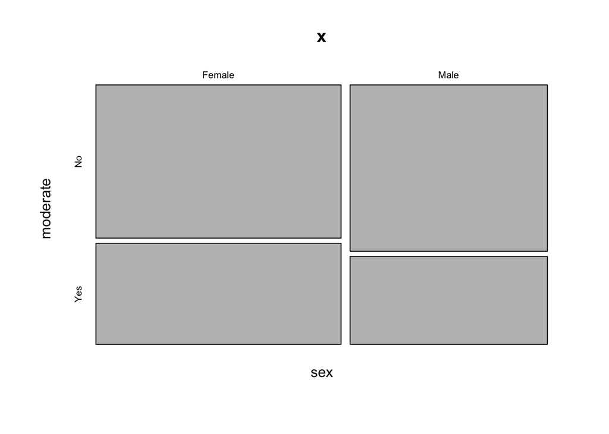

```r
x$moderate <- factor(ifelse(x$polviews == "Moderate", "Yes", "No"))
mosaicplot(sex ~ moderate, data=x)
```

```r
# compute proportions using `apply()`
tbl <- table(x$moderate, x$sex)
tbl
```

```
##
##       Female Male
##   No     920  804
##   Yes    607  425
```

```r
tbl[2,]/apply(tbl, 2, sum)
```

```
##    Female      Male
## 0.3975115 0.3458096
```

Model 1:

```r
m1 <- glm(moderate ~ sex, data=x, family=binomial)
summary(m1)
```

```
##
## Call:
## glm(formula = moderate ~ sex, family = binomial, data = x)
##
## Deviance Residuals:
##     Min       1Q   Median       3Q      Max
## -1.0067  -1.0067  -0.9213   1.3583   1.4573
##
## Coefficients:
##             Estimate Std. Error z value Pr(>|z|)
## (Intercept) -0.41584    0.05229  -7.952 1.83e-15 ***
## sexMale     -0.22167    0.07957  -2.786  0.00534 **
## ---
## Signif. codes:  0 '***' 0.001 '**' 0.01 '*' 0.05 '.' 0.1 ' ' 1
##
## (Dispersion parameter for binomial family taken to be 1)
##
##     Null deviance: 3645.0  on 2755  degrees of freedom
## Residual deviance: 3637.2  on 2754  degrees of freedom
##   (111 observations deleted due to missingness)
## AIC: 3641.2
##
## Number of Fisher Scoring iterations: 4
```

How well does this model predict `moderate`?

```r
table(m1$fitted)
```

```
##
## 0.345809601301892 0.397511460379829
##              1229              1527
```

This tells us there are just 2 distinct predictions for the probability that of someone being a moderate. This is not so helpful for generating individual predictions.

```r
m2 <- glm(moderate ~ sex + age, data=x, family=binomial)
summary(m2)
```

```
##
## Call:
## glm(formula = moderate ~ sex + age, family = binomial, data = x)
##
## Deviance Residuals:
##     Min       1Q   Median       3Q      Max
## -1.5960  -0.9804  -0.8169   1.2872   2.1081
##
## Coefficients:
##                  Estimate Std. Error z value Pr(>|z|)
## (Intercept)     1.192e-01  8.190e-01   0.145  0.88432
## sexMale        -2.383e-01  8.203e-02  -2.905  0.00367 **
## age19          -3.227e-01  8.955e-01  -0.360  0.71858
## age20          -1.122e+00  9.444e-01  -1.188  0.23484
## age21          -9.942e-02  8.937e-01  -0.111  0.91143
## age22           6.071e-14  8.771e-01   0.000  1.00000
## age23          -1.207e-01  8.688e-01  -0.139  0.88954
## age24          -1.938e-01  8.898e-01  -0.218  0.82756
## age25          -1.295e-01  8.632e-01  -0.150  0.88074
## age26          -8.849e-02  8.773e-01  -0.101  0.91965
## age27          -7.936e-01  8.690e-01  -0.913  0.36115
## age28          -2.489e-01  8.766e-01  -0.284  0.77646
## age29          -8.136e-01  8.686e-01  -0.937  0.34893
## age30          -4.762e-01  8.664e-01  -0.550  0.58253
## age31          -8.070e-01  8.664e-01  -0.931  0.35160
## age32          -4.391e-01  8.786e-01  -0.500  0.61722
## age33          -5.126e-01  8.708e-01  -0.589  0.55607
## age34          -1.352e-01  8.668e-01  -0.156  0.87603
## age35          -4.712e-01  8.644e-01  -0.545  0.58568
## age36          -3.929e-01  8.663e-01  -0.454  0.65012
## age37          -1.111e+00  8.744e-01  -1.270  0.20401
## age38          -4.347e-01  8.756e-01  -0.496  0.61957
## age39           1.535e-01  8.778e-01   0.175  0.86118
## age40          -3.636e-01  8.737e-01  -0.416  0.67731
## age41          -7.170e-02  8.893e-01  -0.081  0.93574
## age42          -5.674e-01  8.726e-01  -0.650  0.51555
## age43          -5.835e-01  8.754e-01  -0.667  0.50508
## age44          -5.978e-01  8.727e-01  -0.685  0.49336
## age45          -2.849e-01  9.122e-01  -0.312  0.75481
## age46          -5.841e-01  8.792e-01  -0.664  0.50647
```

[output cut: 40 more lines]

```
## age87           1.307e-01  1.059e+00   0.123  0.90174
## age88           7.350e-01  1.474e+00   0.499  0.61808
## age89 or older  3.133e-01  9.411e-01   0.333  0.73922
## ageNo answer    8.262e-01  1.071e+00   0.772  0.44039
## ---
## Signif. codes:  0 '***' 0.001 '**' 0.01 '*' 0.05 '.' 0.1 ' ' 1
##
## (Dispersion parameter for binomial family taken to be 1)
##
##     Null deviance: 3645  on 2755  degrees of freedom
## Residual deviance: 3539  on 2682  degrees of freedom
##   (111 observations deleted due to missingness)
## AIC: 3687
##
## Number of Fisher Scoring iterations: 4
```

```r
# oops, age  needs to be numeric
x$age <- as.numeric(x$age)
m2 <- glm(moderate ~ sex + age, data=x, family=binomial)
summary(m2)
```

```
##
## Call:
## glm(formula = moderate ~ sex + age, family = binomial, data = x)
##
## Deviance Residuals:
##     Min       1Q   Median       3Q      Max
## -1.1025  -0.9763  -0.8977   1.3666   1.6057
##
## Coefficients:
##              Estimate Std. Error z value Pr(>|z|)
## (Intercept) -0.033515   0.124547  -0.269 0.787853
## sexMale     -0.223486   0.080347  -2.782 0.005411 **
## age         -0.008067   0.002300  -3.508 0.000451 ***
## ---
## Signif. codes:  0 '***' 0.001 '**' 0.01 '*' 0.05 '.' 0.1 ' ' 1
##
## (Dispersion parameter for binomial family taken to be 1)
##
##     Null deviance: 3599.2  on 2726  degrees of freedom
## Residual deviance: 3579.8  on 2724  degrees of freedom
##   (140 observations deleted due to missingness)
## AIC: 3585.8
##
## Number of Fisher Scoring iterations: 4
```

How many unique predicted probabilities are there now? I would assume this is one for every combination of sex and age.

```r
length(unique(fitted(m2)))
```

```
## [1] 142
```

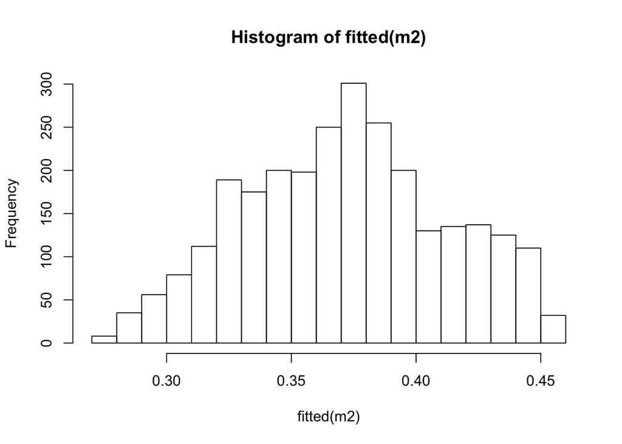

```r
hist(fitted(m2))
```

A plot of the model:

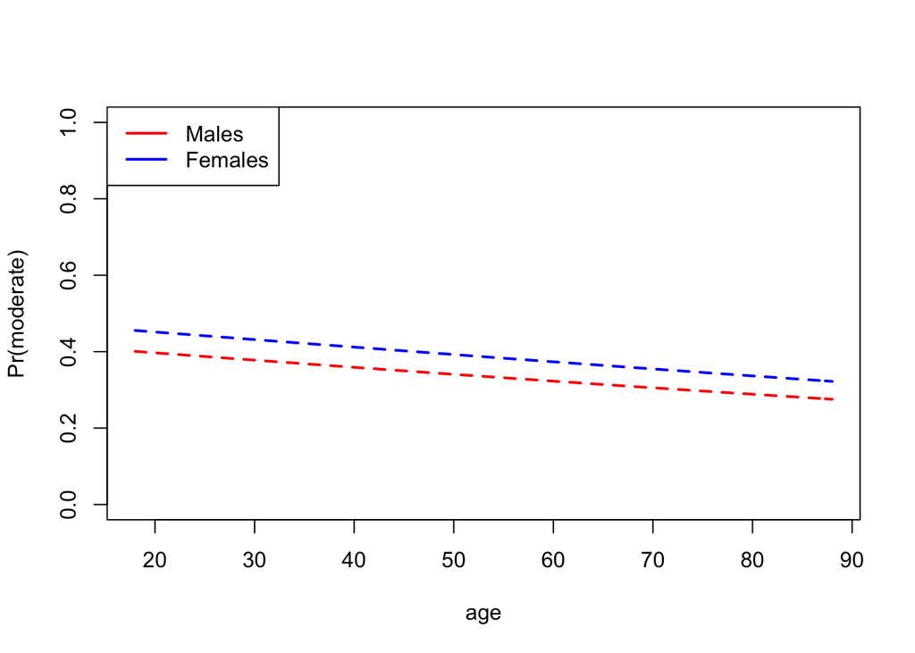

```r
plot(I(moderate == "Yes") ~ age, data=x, type="n", ylab="Pr(moderate)")
curve(predict(m2, data.frame(sex="Female", age=x),
              type="response"), lwd=2, col="blue", lty=2, add=TRUE)
curve(predict(m2, data.frame(sex="Male", age=x),
              type="response"), lwd=2, col="red", lty=2, add=TRUE)

legend("topleft", lwd=2, col=c("red", "blue"), legend=c("Males", "Females"))
```

Let’s look at the fitted values:

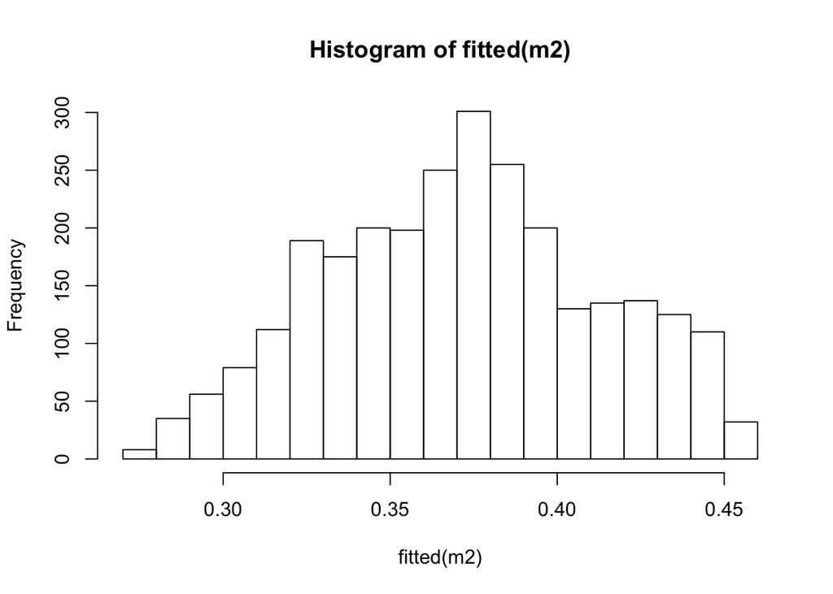

```r
hist(fitted(m2))
```

For the sake of an example, let’s use 0.38 as a threshold for classifying someone as a moderate.

```r
library(dplyr)
y <- x %>% filter(!is.na(age) & !is.na(sex) & !is.na(moderate))
m2a <- glm(moderate ~ sex + age, data=y, family=binomial)
summary(m2a)
```

```
##
## Call:
## glm(formula = moderate ~ sex + age, family = binomial, data = y)
##
## Deviance Residuals:
##     Min       1Q   Median       3Q      Max
## -1.1025  -0.9763  -0.8977   1.3666   1.6057
##
## Coefficients:
##              Estimate Std. Error z value Pr(>|z|)
## (Intercept) -0.033515   0.124547  -0.269 0.787853
## sexMale     -0.223486   0.080347  -2.782 0.005411 **
## age         -0.008067   0.002300  -3.508 0.000451 ***
## ---
## Signif. codes:  0 '***' 0.001 '**' 0.01 '*' 0.05 '.' 0.1 ' ' 1
##
## (Dispersion parameter for binomial family taken to be 1)
##
##     Null deviance: 3599.2  on 2726  degrees of freedom
## Residual deviance: 3579.8  on 2724  degrees of freedom
## AIC: 3585.8
##
## Number of Fisher Scoring iterations: 4
```

```r
pred <- ifelse(fitted(m2a) >= 0.38, "Yes", "No")

# confusion matrix
table(pred=pred, actual=y$moderate)
```

```
##      actual
## pred    No  Yes
##   No  1057  546
##   Yes  656  468
```

```r
#misclassification error rate
mean(pred != y$moderate)
```

```
## [1] 0.4407774
```

What was the misclassification error rate from our smaller model?

```r
m1a <- glm(moderate ~ sex, data=y, family=binomial)
summary(m1a)
```

```
##
## Call:
## glm(formula = moderate ~ sex, family = binomial, data = y)
##
## Deviance Residuals:
##     Min       1Q   Median       3Q      Max
## -1.0005  -1.0005  -0.9192   1.3653   1.4598
##
## Coefficients:
##             Estimate Std. Error z value Pr(>|z|)
## (Intercept) -0.43145    0.05265  -8.194 2.52e-16 ***
## sexMale     -0.21153    0.08009  -2.641  0.00826 **
## ---
## Signif. codes:  0 '***' 0.001 '**' 0.01 '*' 0.05 '.' 0.1 ' ' 1
##
## (Dispersion parameter for binomial family taken to be 1)
##
##     Null deviance: 3599.2  on 2726  degrees of freedom
## Residual deviance: 3592.2  on 2725  degrees of freedom
## AIC: 3596.2
##
## Number of Fisher Scoring iterations: 4
```

```r
pred <- ifelse(fitted(m1a) >= 0.38, "Yes", "No")

# confusion matrix
table(pred=pred, actual=y$moderate)
```

```
##      actual
## pred   No Yes
##   No  797 419
##   Yes 916 595
```

```r
#misclassification error rate
mean(pred != y$moderate)
```

```
## [1] 0.489549
```

Idea is to, say, split the data into 5 parts.

- Fit the model on parts 1-4, predict part 5.
- Fit the model on parts 1-3, 5, predict part 4. …

Come up with a single error measure based on these 5 sets of predictions.

```r
set.seed(230)
y$fold <- sample(c(rep(1:5, 545), 1:2))
table(y$fold)
```

```
##
##   1   2   3   4   5
## 546 546 545 545 545
```

```r
errs1 <- c()
errs2 <- c()
for (k in 1:5) {
  train <- y[y$fold != k,]
  test <- y[y$fold == k,]

  m1b <- glm(moderate ~ sex, data=train, family=binomial)
  preds1 <- ifelse(predict(m1b, test, type="response") >= 0.38,
                   "Yes", "No")
  errs1 <- c(errs1, test$moderate != preds1)
  m2b <- glm(moderate ~ sex + age, data=train, family=binomial)
  preds2 <- ifelse(predict(m2b, test, type="response") >= 0.38,
                   "Yes", "No")
  errs2 <- c(errs2, test$moderate != preds2)
}
mean(errs1) # cross-validation error for model 1
```

```
## [1] 0.489549
```

```r
mean(errs2) # cross-validation error for model 2
```

```
## [1] 0.459846
```

Note: this approach can be used more generally for comparing any two models, for getting a good estimate of the out-of-sample prediction error, and for tuning model parameters, such as the classification threshold.

### Conservatives, Moderates, and Liberals via Logistic Regression

#### (Unordered) Multinomial Logistic Regression

```r
table(x$polviews)
```

```
##
## Conservative     Moderate      Liberal
##          928         1032          796
```

For now, we will ignore the fact that there is a natural (and informative) ordering in response variable `polviews` and fit a multinomial logistic regression.

```r
library(nnet)
m4 <- multinom(polviews ~ age, data=y)
coef(m4)
```

```
##          (Intercept)         age
## Moderate   0.8852288 -0.01588287
## Liberal    0.7137770 -0.01756377
```

The fitted model includes the following equations:

$$\log\left( \frac{\hat p_{Mod}}{\hat p_{Cons}}\right) = 0.885 - 0.016 age$$
$$\log\left( \frac{\hat p_{Lib}}{\hat p_{Cons}}\right) = 0.714 - 0.018 age$$

- We expect that someone is $e^{0.714}=2.04$ times as likely to be born a Liberal as a Conservative.
- As age increases by 1 year, the log-odds ratio of being a liberal versus a conservative decreases by 0.018 (or the odds ratio gets multiplied by $e^{-0.018}=0.98$).

What are the predicted class probabilities for someone who is age 50?

$$\log\left( \frac{\hat p_{Mod}}{\hat p_{Cons}}\right) = 0.885 - 0.016 (50) = 0.085$$

$$\hat p_{Mod} = \hat p_{Cons} e^{0.085} = 1.089 \hat p_{Cons}$$

$$\log\left( \frac{\hat p_{Lib}}{\hat p_{Cons}}\right) = 0.714 - 0.018 (50) = -0.186$$

$$\hat p_{Lib} = \hat p_{Cons} e^{-0.186} = 0.830\hat p_{Cons}$$

We also know that $\hat p_{Lib} + \hat p_{Cons} + \hat p_{Mod} = 1$, so we can solve:

$$\hat p_{Cons} + 1.089 \hat p_{Cons} + 0.830\hat p_{Cons} = 1 \ \ \ \Rightarrow \hat p_{Cons} = 0.343$$

```r
predict(m4, data.frame(age=50), type="class")
```

```
## [1] Moderate
## Levels: Conservative Moderate Liberal
```

```r
predict(m4, data.frame(age=50), type="probs")
```

```
## Conservative     Moderate      Liberal
##    0.3397022    0.3720970    0.2882009
```

Let’s try to visualize the model:

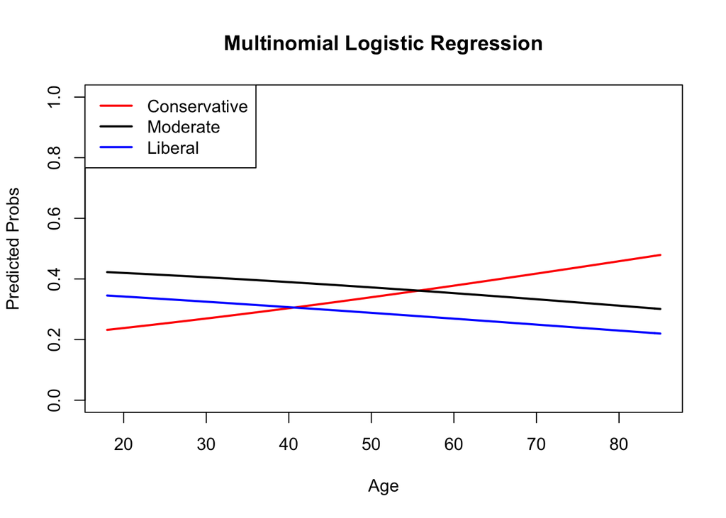

```r
plot(c(18,85), c(0,1), type="n", xlab="Age", ylab="Predicted Probs", main="Multinomial Logistic Regression")
curve(predict(m4, data.frame(age=x), type="probs")[,1],
      col="red", lwd=2, add=TRUE)
curve(predict(m4, data.frame(age=x), type="probs")[,2],
      col="black", lwd=2, add=TRUE)
curve(predict(m4, data.frame(age=x), type="probs")[,3],
      col="blue", lwd=2, add=TRUE)
legend("topleft", col=c("red", "black", "blue"), lwd=2, legend=levels(x$polviews))
```

In general, with K classes in the response variable and p predictors, we expect to have (K-1)*(p+1).

#### Ordinal Logistic Regression

Ordinal logistic regression is applicable in cases where the response variable has a natural (and informative) ordering.

```r
library(MASS)
p1 <- polr(polviews ~ age, data=y)
summary(p1)
```

```
##
## Re-fitting to get Hessian
```

```
## Call:
## polr(formula = polviews ~ age, data = y)
##
## Coefficients:
##        Value Std. Error t value
## age -0.01323   0.002047  -6.464
##
## Intercepts:
##                       Value    Std. Error t value
## Conservative|Moderate  -1.3205   0.1091   -12.0990
## Moderate|Liberal        0.2661   0.1060     2.5105
##
## Residual Deviance: 5921.185
## AIC: 5927.185
```

In general, with $K$ classes and p predictors, we have a total of (K-1)+p coefficients fitted.

Note that `polr()` encodes Y as 3 levels:

- Y=1: Conservative
- Y=2: Moderate
- Y=3: Liberal

The model uses equations that are based on predicting log-odds of **cumulative probabilities** $P(Y \le j)$.

Log odds ratios involve probabilities:

- being in group 1 ($Y \le 1$)
- being in group 1 or 2 ($Y \le 2$)

$$\log \frac{P(Y\le 1)}{1-P(Y \le 1)} = \alpha_1 - (\beta_1\text{age})$$

$$\log \frac{P(Y\le 2)}{1- P(Y \le 2)} = \alpha_2 - (\beta_1\text{age})$$

- $\alpha_k$ is the log-odds of falling into or below category $k$ when the explanatory variables are 0.
- $\beta_1$ is the **decrease** in log-odds of falling into or below any category associated with a 1 year increase in `age`. (Positive $beta$ values suggest increase in predictor is associated with lower chance of falling into lower categories.)

Check: What are the predicted class probabilities for a 50-year old?

```r
cumprobs <- rep(NA, 2)

# this is the predicted probability of conservative
cumprobs[1] <- exp(-1.3205 +0.01323*50)
cumprobs[1] <- cumprobs[1] /(1+cumprobs[1] )
cumprobs[1] # P(Y <= 1) = P(Y = 1)
```

```
## [1] 0.3409643
```

```r
# this is the predicted probability of conservative OR moderate
cumprobs[2] <- exp(0.266 +0.01323*50)
cumprobs[2] <- cumprobs[2] /(1+cumprobs[2] )
cumprobs[2] # P(Y <= 2) = P(Y = 1) + P(Y=2)
```

```
## [1] 0.7165678
```

```r
# prob of conservative
cumprobs[1]
```

```
## [1] 0.3409643
```

```r
# prob of moderate
cumprobs[2] - cumprobs[1]
```

```
## [1] 0.3756035
```

```r
# prob of liberal
1-cumprobs[2]
```

```
## [1] 0.2834322
```

```r
# check
predict(p1, data.frame(age=50), type="probs")
```

```
## Conservative     Moderate      Liberal
##    0.3409831    0.3756386    0.2833783
```

Let’s try to visualize the model:

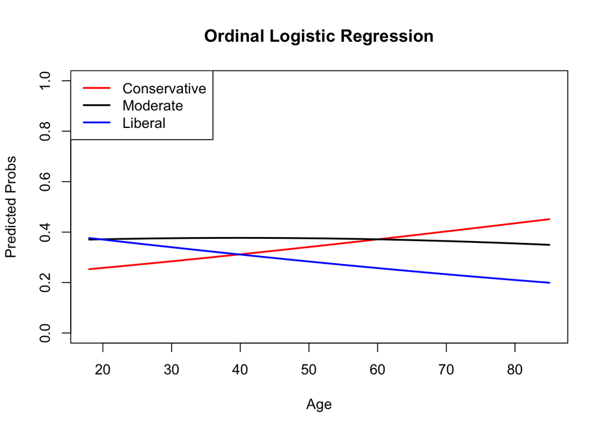

```r
plot(c(18,85), c(0,1), type="n", xlab="Age", ylab="Predicted Probs", main="Ordinal Logistic Regression")
curve(predict(p1, data.frame(age=x), type="probs")[,1],
      col="red", lwd=2, add=TRUE)
curve(predict(p1, data.frame(age=x), type="probs")[,2],
      col="black", lwd=2, add=TRUE)
curve(predict(p1, data.frame(age=x), type="probs")[,3],
      col="blue", lwd=2, add=TRUE)
legend("topleft", col=c("red", "black", "blue"), lwd=2, legend=levels(y$polviews))
```

Let’s take a look at the cumulative probabilities:

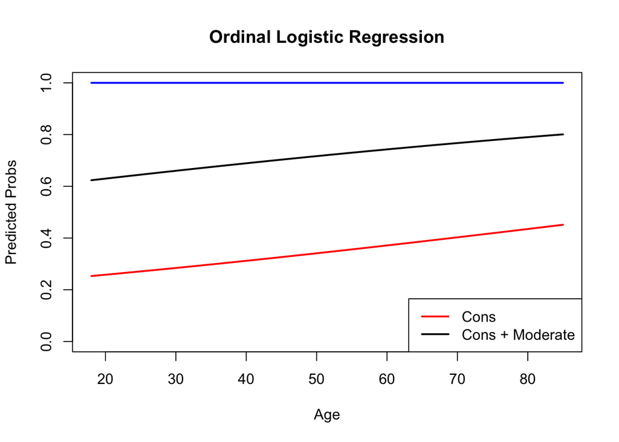

```r
plot(c(18,85), c(0,1), type="n", xlab="Age", ylab="Predicted Probs", main="Ordinal Logistic Regression")
curve(predict(p1, data.frame(age=x), type="probs")[,1],
      col="red", lwd=2, add=TRUE)
curve(rowSums(predict(p1, data.frame(age=x), type="probs")[,1:2]),
      col="black", lwd=2, add=TRUE)
curve(rowSums(predict(p1, data.frame(age=x), type="probs")[,1:3]),
      col="blue", lwd=2, add=TRUE)
llabels <- c("Cons", "Cons + Moderate")
legend("bottomright", col=c("red", "black"), lwd=2, legend=llabels)
```

Interpretation: The distance between 0 and the red curve here gives the probability that someone is a conservative at a given age. The distance between the red and the black curve yields the probability that someone is a moderate at a given age. The distance between the black and blue gives the probability that someone is a liberal at a given age. We see the conservative probabilities growing as we age, suggesting that we’re more likely to be come more conservative as we age, and that the liberal probabilities shrinks as we age. The gap between the red and the black line is fairly constant, so the moderate probabilities are relatively unaffected by age.

Stepwise regression still works!

```r
mfull <- polr(polviews ~ . - fold - hrs1 - moderate, data=y )
mstep <- step(mfull, direction="backward")
```

```
## Start:  AIC=4989.17
## polviews ~ (wrkstat + partyid + happy + rincome + born + race +
##     sex + degree + age + marital + hrs1 + pres12 + moderate +
##     fold) - fold - hrs1 - moderate
##
##           Df    AIC
## - rincome 14 4977.3
## - sex      1 4987.2
## - marital  4 4987.7
## <none>       4989.2
## - born     2 4989.8
## - age      1 4991.6
## - wrkstat  8 4992.1
## - happy    4 4992.8
## - degree   5 5020.8
## - race     2 5021.2
## - pres12   7 5104.1
## - partyid  8 5248.8
##
## Step:  AIC=4977.25
## polviews ~ wrkstat + partyid + happy + born + race + sex + degree +
##     age + marital + pres12
##
##           Df    AIC
## - marital  4 4974.1
## - sex      1 4975.4
## - born     2 4977.2
## <none>       4977.3
## - wrkstat  8 4978.2
## - age      1 4979.2
## - happy    4 4981.0
## - race     2 5008.5
## - degree   5 5010.6
## - pres12   7 5091.7
## - partyid  8 5234.4
##
## Step:  AIC=4974.12
## polviews ~ wrkstat + partyid + happy + born + race + sex + degree +
##     age + pres12
##
```

[output cut: 11 more lines]

```
##
## Step:  AIC=4972.28
## polviews ~ wrkstat + partyid + happy + born + race + degree +
##     age + pres12
##
##           Df    AIC
## <none>       4972.3
## - born     2 4972.6
## - wrkstat  8 4974.5
## - happy    4 4975.3
## - age      1 4978.5
## - race     2 5000.7
## - degree   5 5004.6
## - pres12   7 5087.7
## - partyid  8 5236.4
```